# Analysis of "Bay Wheels" Bike Share System Data between 2017 to 2020

## Step 1: Data Gathering

Because the data files are distributed across multiple urls, I will download them programmatically into a single folder first

```python
# Make directory if it doesn't already exist
folder_name = 'bike_share_data'
if not os.path.exists(folder_name):
    os.makedirs(folder_name)
```

```python
# urls containing the datasets for each month
data_urls = [
    'https://s3.amazonaws.com/baywheels-data/2017-fordgobike-tripdata.csv.zip',
    'https://s3.amazonaws.com/baywheels-data/201801-fordgobike-tripdata.csv.zip',
    'https://s3.amazonaws.com/baywheels-data/201802-fordgobike-tripdata.csv.zip',
    'https://s3.amazonaws.com/baywheels-data/201803-fordgobike-tripdata.csv.zip',
    'https://s3.amazonaws.com/baywheels-data/201804-fordgobike-tripdata.csv.zip',
    'https://s3.amazonaws.com/baywheels-data/201805-fordgobike-tripdata.csv.zip',
    'https://s3.amazonaws.com/baywheels-data/201806-fordgobike-tripdata.csv.zip',
    'https://s3.amazonaws.com/baywheels-data/201807-fordgobike-tripdata.csv.zip',
    'https://s3.amazonaws.com/baywheels-data/201808-fordgobike-tripdata.csv.zip',
    'https://s3.amazonaws.com/baywheels-data/201809-fordgobike-tripdata.csv.zip',
    'https://s3.amazonaws.com/baywheels-data/201810-fordgobike-tripdata.csv.zip',
    'https://s3.amazonaws.com/baywheels-data/201811-fordgobike-tripdata.csv.zip',
    'https://s3.amazonaws.com/baywheels-data/201812-fordgobike-tripdata.csv.zip',
    'https://s3.amazonaws.com/baywheels-data/201901-fordgobike-tripdata.csv.zip',
    'https://s3.amazonaws.com/baywheels-data/201902-fordgobike-tripdata.csv.zip',
    'https://s3.amazonaws.com/baywheels-data/201903-fordgobike-tripdata.csv.zip',
    'https://s3.amazonaws.com/baywheels-data/201904-fordgobike-tripdata.csv.zip',
    'https://s3.amazonaws.com/baywheels-data/201905-baywheels-tripdata.csv.zip',
    'https://s3.amazonaws.com/baywheels-data/201906-baywheels-tripdata.csv.zip',
    'https://s3.amazonaws.com/baywheels-data/201907-baywheels-tripdata.csv.zip',
    'https://s3.amazonaws.com/baywheels-data/201908-baywheels-tripdata.csv.zip',
    'https://s3.amazonaws.com/baywheels-data/201909-baywheels-tripdata.csv.zip',
    'https://s3.amazonaws.com/baywheels-data/201910-baywheels-tripdata.csv.zip',
    'https://s3.amazonaws.com/baywheels-data/201911-baywheels-tripdata.csv.zip',
    'https://s3.amazonaws.com/baywheels-data/201912-baywheels-tripdata.csv.zip',
    'https://s3.amazonaws.com/baywheels-data/202001-baywheels-tripdata.csv.zip',
    'https://s3.amazonaws.com/baywheels-data/202002-baywheels-tripdata.csv.zip',
    'https://s3.amazonaws.com/baywheels-data/202003-baywheels-tripdata.csv.zip']
```

```python
# programmatically downloading and extracting the zip files from urls
for url in data_urls:
    r = requests.get(url)
    z = zipfile.ZipFile(io.BytesIO(r.content))
    z.extractall('/Users/tonyzhang/Desktop/coding practice/Data Analyst/4_Data Visualization/bike_share_data')
```

```python
#open all the .csv files downloaded and concatenating into a single dataframe

path = r'/Users/tonyzhang/Desktop/coding practice/Data Analyst/4_Data Visualization/bike_share_data'
all_files = glob.glob(os.path.join(path, "*.csv"))
df_from_each_file = (pd.read_csv(f) for f in all_files)
bike_df = pd.concat(df_from_each_file, ignore_index=True)
```

## Step 2: Data Analysis

### Summary:

Tidiness Issues:

None

Quality Issues:

1. `bike_share_for_all_trip` should be `True` or `False`
2. quite a few columns contain missing values
3. drop duplicate rows
4. dropping unecessary columns
5. `start_time` and `end_time` should be `datetime`
6. `start_station_id`, `end_station_id` and `bike_id` should be `str`

## Step 3: Data Cleaning

**Quality Issue 1:**

**Define:** `bike_share_for_all_trip` should be a boolean of `True` or `False` instead of `Yes` or `No`

**Code:**

```python
bike_clean.bike_share_for_all_trip = bike_clean.bike_share_for_all_trip.replace(['Yes', 'No'], ['True', 'False'])
```

**Test**:

```python
bike_clean.bike_share_for_all_trip.value_counts()
```

```
False    3787538
True      339907
Name: bike_share_for_all_trip, dtype: int64
```

**Quality Issue 2:**

**Define:** Let's start with the missing values for `start_station_name` and `end_station_name`. I will create a dictionary using the lat/long values (since these are not missing) to fill in the start and end station names, next, I will create a second dictionary of station ID to station names to fill in the missing station ID values.

**Code:**

```python
# filling in missing values for station name with our dictionary

bike_clean['start_station_name'] = bike_clean['start_station_name'].fillna(bike_clean['lat_long'].apply(lambda x: station_id.get(x)))
bike_clean['end_station_name'] = bike_clean['end_station_name'].fillna(bike_clean['lat_long'].apply(lambda x: station_id.get(x)))
bike_clean['start_station_id'] = bike_clean['start_station_id'].fillna(bike_clean['start_station_name'].apply(lambda x: station_id.get(x)))
bike_clean['end_station_id'] = bike_clean['end_station_id'].fillna(bike_clean['end_station_name'].apply(lambda x: station_id.get(x)))
```

**Test:**

**Note:** Unfortunately I was unable to fill in every single missing data for each start/end station name and id using my method, what I managed to recover was:

- `start_station_id`: 5218260 - 5216604 = 1656
- `end_station_id`: 5216580 - 5214956 = 1624
- `start_station_name`: 5218438 - 5218438 = 0
- `end_station_name`: 5216782 - 5216782 = 0

My suspicions as to why the method did not work for all values was due to the fact that some of the coordinates were just not mapped to any stations to begin with, which would of course not be part of the dataset. One of the biggest challenges was also picking an appropriate rounding point for each lat/lon value, as some locations were identical in name, but had differing lat/long values up to the 3rd or 4th decimal points.

One other strategy that would potentially work is to perform reverse geocoding on each coordinate to get its location using the geopy library, however, with over 5million+ data points, the standard built in API would not be feasible.

Therefore, although unfortunate, I think maybe the best solution would be to drop all of the missing values with reference to `start_station_id` (this column contains the most missing values), as we will be using the station names as part of our analysis.

```python
# dropping all missing values in reference to start_station_id
bike_clean = bike_clean[bike_clean['start_station_id'].notna()]
```

**Observation:** Alright, most of the missing values have been removed, in total we removed approximately 12% of the original data due to unrecoverable missing values. We are also missing data for `bike_share_for_all_trip` and `rental_access_method`, however these data are not recoverable and removing these missing values will be too "expensive" as it will largely diminish the size of our current df. Therefore, we'll just leave it.

**Quality Issue 3:**

**Define:** dropping all the duplicated rows

**Code:**

```python
bike_clean = bike_clean.drop_duplicates()
```

**Test:**

```python
sum(bike_clean.duplicated())
```

```
0
```

**Quality Issue 4, 5 and 6:**

**Define:** First we will drop columns which will not contribute to our analysis, then we will change the datatypes of each column to the appropriate type

**Code:**

```python
bike_clean = bike_clean.drop(['lat_long'], axis=1)
```

```python
bike_clean.start_time = pd.to_datetime(bike_clean.start_time)
bike_clean.end_time = pd.to_datetime(bike_clean.end_time)
bike_clean.start_station_id = bike_clean.start_station_id.astype('int').astype('str')
bike_clean.end_station_id = bike_clean.end_station_id.astype('int').astype('str')
bike_clean.bike_id = bike_clean.bike_id.astype('int').astype('str')
```

**Test:**

```python
bike_clean.info(verbose=True, null_counts=True)
```

```
<class 'pandas.core.frame.DataFrame'>
Int64Index: 5125741 entries, 0 to 5795410
Data columns (total 15 columns):
 #   Column                   Non-Null Count    Dtype
---  ------                   --------------    -----
 0   duration_sec             5125741 non-null  int64
 1   start_time               5125741 non-null  datetime64[ns]
 2   end_time                 5125741 non-null  datetime64[ns]
 3   start_station_id         5125741 non-null  object
 4   start_station_name       5125741 non-null  object
 5   start_station_latitude   5125741 non-null  float64
 6   start_station_longitude  5125741 non-null  float64
 7   end_station_id           5125741 non-null  object
 8   end_station_name         5125741 non-null  object
 9   end_station_latitude     5125741 non-null  float64
 10  end_station_longitude    5125741 non-null  float64
 11  bike_id                  5125741 non-null  object
 12  user_type                5125741 non-null  object
 13  bike_share_for_all_trip  4114929 non-null  object
 14  rental_access_method     81542 non-null    object
dtypes: datetime64[ns](2), float64(4), int64(1), object(8)
memory usage: 625.7+ MB
```

## Step 4: Exploratory Data Analysis

### 1. Univariate Analysis:

After having time to think and play with the data, I feel like most of the interesting analysis for this dataset may be univariate in nature, as from the perspective of the company, they may be interested in learning more about "counts" than relationships. I will spend most of the time in this section.

1. What's the distribution of trip duration?
2. whats the distribution of distance per trip?
3. what's the distribution for the amount of trips per bike?
4. what are the most popular stations?
5. what's the most popular trip? (in terms of start and stop locations)
6. what are the busiest time of day and day of the week for share bikes?
7. what are the difference in the number of each user type

#### Question 1. What's the distribution of trip duration?

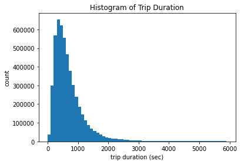

```python
bin_edges = np.arange(0, 6000, 100)
plt.hist(data=bike_clean, x='duration_sec', bins=bin_edges);
plt.title('Histogram of Trip Duration');
plt.ylabel('count')
plt.xlabel('trip duration (sec)');
```

#### Question 2: whats the distribution of distance per trip?

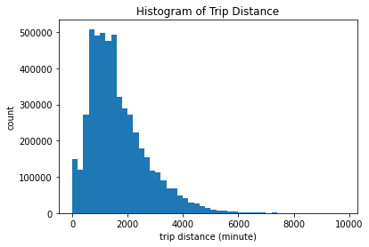

```python
bin_edges = np.arange(0, 10000, 200)
plt.hist(data=bike_clean, x='trip_dist', bins=bin_edges);
plt.title('Histogram of Trip Distance');
plt.ylabel('count')
plt.xlabel('trip distance (minute)');
```

**Observation:** Similar to trip duration, the distribution of trip distance is right skewed

#### Question 3: what's the distribution for the amount of trips per bike?

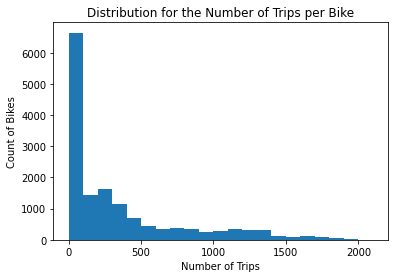

```python
#bike_clean.bike_id.value_counts().hist();
bin_edges = np.arange(0, bike_clean.bike_id.value_counts().max()+100, 100)
plt.hist(bike_clean.bike_id.value_counts(), bins=bin_edges);
plt.title('Distribution for the Number of Trips per Bike')
plt.ylabel('Count of Bikes')
plt.xlabel('Number of Trips');
```

**Observation:** The distribution of bike usage is also right skewed, with over 6000 sharebikes having only around 100 trips, while the average number of trips per bike is 434. This tells us that there are a lot of new bikes in the rotation.

#### Question 4: what are the most popular stations?

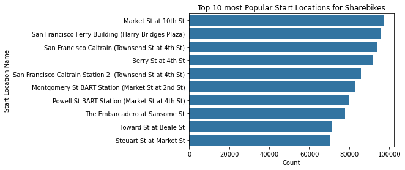

```python
# plotting the 10 most popular start stations by count
order = bike_clean['start_station_name'].value_counts()[0:10].sort_values(ascending=False).index
bike_start = bike_clean[bike_clean['start_station_name'].isin(order)]
base_color = sns.color_palette()[0]
sns.countplot(data=bike_start, y='start_station_name', color=base_color, order = order);
plt.title('Top 10 most Popular Start Locations for Sharebikes')
plt.ylabel('Start Location Name')
plt.xlabel('Count');
```

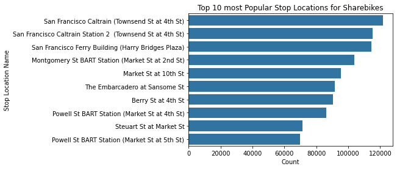

```python
# plotting the 10 most popular end stations by count
order = bike_clean['end_station_name'].value_counts()[0:10].sort_values(ascending=False).index
bike_start = bike_clean[bike_clean['end_station_name'].isin(order)]
base_color = sns.color_palette()[0]
sns.countplot(data=bike_start, y='end_station_name', color=base_color, order = order);
plt.title('Top 10 most Popular Stop Locations for Sharebikes')
plt.ylabel('Stop Location Name')
plt.xlabel('Count');
```

**Analysis:** The top 10 most popular start stations and end stations are 90% alike, which could represent areas of high population density/popular city spots. This information may be most useful when deciding where to allocate more share bikes. In particular we can deduce some interesting observations from comparing the two charts such as more people use the sharebikes to go to the San Francisco Caltrain station than using it to leave.

#### Questions 5: what's the most popular trip? (in terms of start and stop locations)

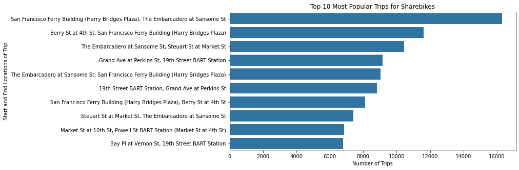

```python
plt.figure(figsize=[10,5])
order = bike_clean['trip'].value_counts()[0:10].sort_values(ascending=False).index
bike_start = bike_clean[bike_clean['trip'].isin(order)]
base_color = sns.color_palette()[0]
sns.countplot(data=bike_start, y='trip', color=base_color, order = order);
plt.title('Top 10 Most Popular Trips for Sharebikes')
plt.ylabel('Start and End Locations of Trip')
plt.xlabel('Number of Trips');
```

**Analysis:** the trip between the San Francisco Ferry Building and the Embarcadero at Sansome St. is by far the most popular trip

#### Question 6. what are the busiest time of day and day of the week for share bikes?

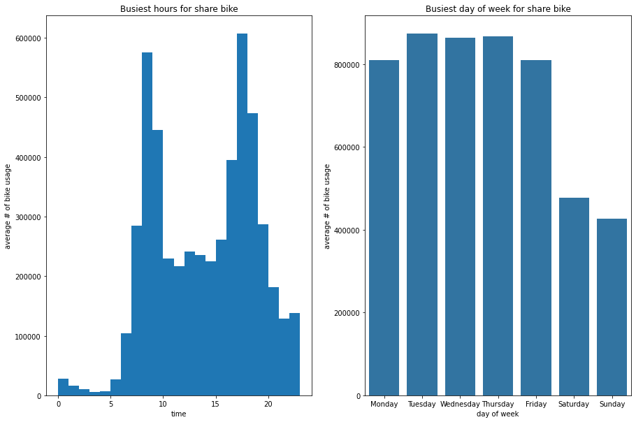

```python
plt.figure(figsize=[15,10])

#left plot is hours of day
plt.subplot(1,2,1)
bin_edges = np.arange(0, 24, 1)
plt.hist(data=bike_clean, x='start_hour', bins=bin_edges);
plt.title('Busiest hours for share bike');
plt.ylabel('average # of bike usage')
plt.xlabel('time');

#right plot is day of week
plt.subplot(1,2,2)
sns.countplot(data=bike_clean, x='day_of_week', color=base_color, order = ['Monday','Tuesday','Wednesday','Thursday',
                                                                          'Friday', 'Saturday', 'Sunday'])
plt.title('Busiest day of week for share bike');
plt.ylabel('average # of bike usage')
plt.xlabel('day of week');
```

**Observation:** from the distribution of time of day, we see that the two peaks correspond to 8 am and 5 pm, which represents morning and afternoon rush hours.For day of week, there are a lot more users on weekdays than weekends, which may suggest that people use it mostly for work related commutes

#### Question 7: what are the differences between the number of user types?

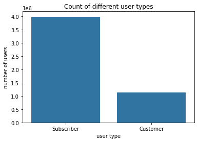

```python
sns.countplot(data=user_type, x='user_type', color=base_color)
plt.title('Count of different user types');
plt.ylabel('number of users')
plt.xlabel('user type');
```

**Observation:** there are a lot more subscribers than there are customers

### 2. Bivariate Analysis:

1. what is the relationship between trip duration and trip length?
2. what's the distance of the 10 most popular trips?
3. what's the relationship between day of the week and trip length/trip duration

#### Question 1: what is the relationship between trip duration and trip length?

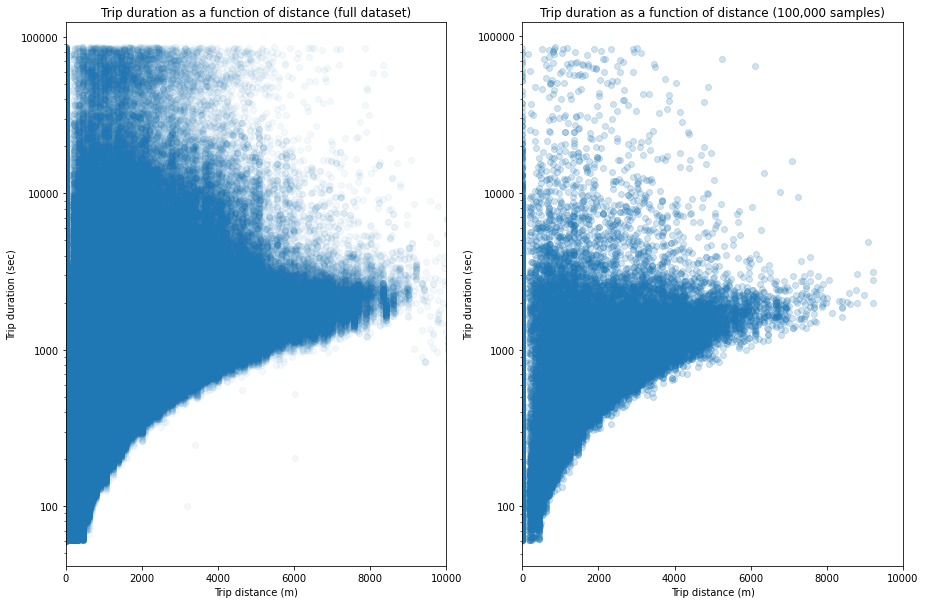

```python
plt.figure(figsize=[15,10])

#no sampling
plt.subplot(1,2,1)
ax = sns.regplot(data=bike_clean, x = 'trip_dist', y = 'duration_sec', fit_reg=False,
                 x_jitter = 0.1, y_jitter = 0.1, scatter_kws = {'alpha':0.05});
plt.yscale('log')
tick_locs = [100, 1000, 10000, 100000]
plt.yticks(tick_locs, tick_locs)
ax.set_xlim(0,10000);
plt.title('Trip duration as a function of distance (full dataset)')
plt.xlabel('Trip distance (m)')
plt.ylabel('Trip duration (sec)');

#sampling used
plt.subplot(1,2,2)
sample_df = bike_clean.sample(100000)
ax = sns.regplot(data=sample_df, x = 'trip_dist', y = 'duration_sec', fit_reg=False,
                 x_jitter = 0.2, y_jitter = 0.2, scatter_kws = {'alpha':0.2});
plt.yscale('log')
tick_locs = [100, 1000, 10000, 100000]
plt.yticks(tick_locs, tick_locs)
ax.set_xlim(0,10000);
plt.title('Trip duration as a function of distance (100,000 samples)')
plt.xlabel('Trip distance (m)')
plt.ylabel('Trip duration (sec)');
```

**Analysis**: despite all the noise, we can observe from this plot that there is a positive relationship between the distance and duration of a trip. I've set the trip distance to a maximum of 10km as there were many outlier outside of this range and extreme distances. Also notice the vertical line at a trip distance of 0, which may indicate that a bike was activated but not used, or used for minutely small distances.

#### Question 2: what's the distance of the 10 most popular trips?

[figure not shown]

```python
# for our investigation of x=cat_var and y=num_var, a barplot may be best
plt.figure(figsize=[10,5])
sns.barplot(data=toptrip_df, y = 'trip', x='trip_dist', color=base_color);
plt.title('Distances of the 10 most popular trips')
plt.xlabel('Trip distance (m)')
plt.ylabel('Start and end stations of trip');
```

**Observations:** of the 10 most popular trips, the maximum commute length is just over 2000 meters

#### Question 3: what's the relationship between day of the week and trip length/trip duration

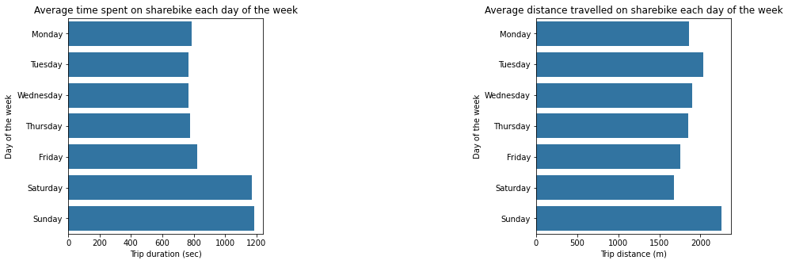

```python
plt.figure(figsize=[15,5])


#left plot is DOF and trip length
plt.subplot(1,3,1)
sns.barplot(data=DOF_time, x = 'duration_sec', y=DOF_time.index, color=base_color, order = ['Monday','Tuesday','Wednesday','Thursday',
                                                                          'Friday', 'Saturday', 'Sunday']);
plt.title('Average time spent on sharebike each day of the week')
plt.xlabel('Trip duration (sec)')
plt.ylabel('Day of the week');

#left plot is DOF and trip duration
plt.subplot(1,3,3)
sns.barplot(data=DOF_dist, x = 'trip_dist', y=DOF_dist.index, color=base_color, order = ['Monday','Tuesday','Wednesday','Thursday',
                                                                          'Friday', 'Saturday', 'Sunday']);
plt.title('Average distance travelled on sharebike each day of the week')
plt.xlabel('Trip distance (m)')
plt.ylabel('Day of the week');
```

**Analysis:** It seems that people on average spend more time on sharebikes during weekends than weekdays, even though there are more usage during weekdays. For the distance, the order seems unintuitive. Tuesdays have the highest distanced travelled after Sunday, which seems kind of weird

### 3. Multivariate Analysis:

1. what is the difference between user_type in the average time spent of the bike each day of the week?
2. what is the difference between user_type in the average trip distance of the bike each day of the week?

#### Question 1: what is the difference between user_type in the average time spent of the bike each day of the week?

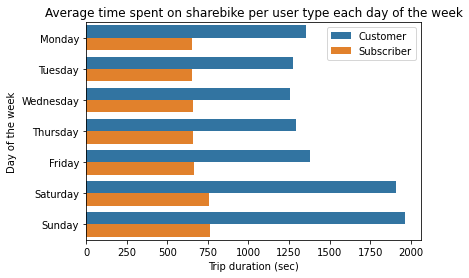

```python
sns.barplot(data=user_DOF_time, x = 'duration_sec', y='day_of_week', hue='user_type', order = ['Monday','Tuesday','Wednesday','Thursday',
                                                                          'Friday', 'Saturday', 'Sunday']);
plt.title('Average time spent on sharebike per user type each day of the week')
plt.xlabel('Trip duration (sec)')
plt.ylabel('Day of the week');
plt.legend();
```

**Observation**: customers (casual) spend a lot more time on the bikes over subscribers (members), both user types follow the same trip per day of week however.

#### Question 2: what is the difference between user_type in the average travel distance of the bike each day of the week?

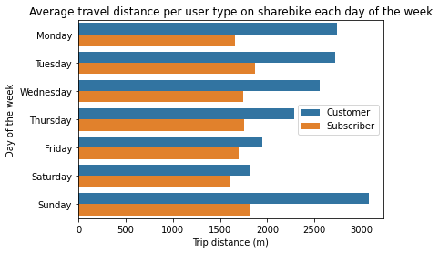

```python
sns.barplot(data=user_DOF_dist, x = 'trip_dist', y='day_of_week', hue='user_type', order = ['Monday','Tuesday','Wednesday','Thursday',
                                                                          'Friday', 'Saturday', 'Sunday']);
plt.title('Average travel distance per user type on sharebike each day of the week')
plt.xlabel('Trip distance (m)')
plt.ylabel('Day of the week');
plt.legend();
```

**Observations:** simialr to time, customers on average have longer trips over subscribers, however the discrepancies are much smaller, especially during Friday and Saturday

## Step 5: Saving our final dataset

```python
bike_clean.to_csv('BayWheels_data_clean.csv', index = False)
```